# Case study report for Age at menopause

09 July 2022

**Report for: Age at menopause (ukb-b-17422)**

This case study report includes the results for Age at menopause, generated automatically using Rmarkdown.

The report is split into 3(+1) parts:

1. Mendelian randomization (MR) results for Age at menopause for all breast cancer outcomes (BCAC 2017 and 2020)
2. Overview of potential mediators identified from MR-EvE data; their validation with two-step and multivariable MR (MVMR)
3. Overview of potential mediators identified from literature-mined data; their validation with two-step, bidirectional, and MVMR
4. *Optional* validation of results with female-only exposure data (if available)
- Trait IDs in this report correspond to data available in [OpenGWAS](https://gwas.mrcieu.ac.uk/)
- BCAC 2017 outcomes names/IDs: Full sample (“Breast cancer”) `ieu-a-1126`, ER+ sample (“ER+ Breast cancer”)`ieu-a-1127`, ER- sample (“ER- Breast cancer”) `ieu-a-1128`
- MR analyses in this report were performed using TwoSampleMR and MVMR packages
- The two-sample MR estimates presented in this report were produced with inverse-variance weighted (IVW) or Wald ratio (for single SNP traits)

This report is a part of the publication *“Integrating Mendelian randomization and literature-mined evidence for breast cancer risk factors”* Vabistsevits et al 2022

# 1 Main analysis MR results

Age at menopause data details:

- Source: UK Biobank
- Sample size: 143K
- nSNPs: 102
- Sample sex: female

Age at menopause was identified in MR-EvE search as having evidence of effect on breast cancer and validated with IVW MR method in BCAC 2017 and BCAC 2020 breast cancer outcomes:

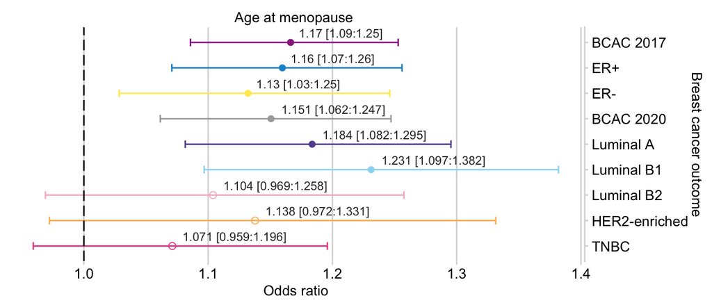

| exposure | outcome | IVW OR | pval | nsnp | Egger intercept < 0.05 | Heterogeneity Qpval < 0.05 |
| --- | --- | --- | --- | --- | --- | --- |
| Age at menopause | BCAC 2017 | 1.17 [1.09:1.25] | 2.5e-05 | 102 | TRUE | TRUE |
| Age at menopause | ER+ | 1.16 [1.07:1.26] | 2.7e-04 | 102 | TRUE | TRUE |
| Age at menopause | ER- | 1.13 [1.03:1.25] | 1.1e-02 | 102 | TRUE | TRUE |
| Age at menopause | BCAC 2020 | 1.151 [1.062:1.247] | 6.4e-04 | 87 | TRUE | TRUE |
| Age at menopause | Luminal A | 1.184 [1.082:1.295] | 2.5e-04 | 86 | TRUE | TRUE |
| Age at menopause | Luminal B1 | 1.231 [1.097:1.382] | 4.2e-04 | 86 | TRUE | TRUE |
| Age at menopause | Luminal B2 | 1.104 [0.969:1.258] | 1.4e-01 | 86 | TRUE | TRUE |
| Age at menopause | HER2-enriched | 1.138 [0.972:1.331] | 1.1e-01 | 86 | TRUE | FALSE |
| Age at menopause | TNBC | 1.071 [0.959:1.196] | 2.2e-01 | 86 | TRUE | TRUE |

The full MR results and sensitivity analysis are available in Supplementary Data 2 and 3.

# 2 MR-EvE-mined mediators

By querying MR-EvE data for Age at menopause we identified 2 potential mediators. This analysis was done only for BCAC 2017 outcomes (full / ER+ / ER-), and only those that were affected in the main MR analysis: full , ER+ , ER- sample(s)

Below is a table of two-step MR results for each mediator, including *exposure -> mediator* and *mediator -> outcome*. The total effect of *exposure -> outcome* is available in the table above.

## 2.1 Two-step MR

**Full sample**: 2 potential mediators from MR-EvE

| exposure | outcome | mediator.id | mediator | exposure -> mediator (step1) beta_CI | nSNPs (step1) | mediator -> outcome (step2) OR_CI | nSNPs (step2) |
| --- | --- | --- | --- | --- | --- | --- | --- |
| Age at menopause (last menstrual period) | BCAC 2017 | ukb-a-316 | Had menopause | -0.14 [-0.15:-0.13] | 107 | 0.31 [0.09:0.99] | 7 |
| Age at menopause (last menstrual period) | BCAC 2017 | met-a-517 | X-11445--5-alpha-pregnan-3beta,20alpha-disulfate | 0.06 [0:0.11] | 80 | 0.82 [0.7:0.96] | 2 |

**ER+ sample**: 1 potential mediators from MR-EvE

| exposure | outcome | mediator.id | mediator | exposure -> mediator (step1) beta_CI | nSNPs (step1) | mediator -> outcome (step2) OR_CI | nSNPs (step2) |
| --- | --- | --- | --- | --- | --- | --- | --- |
| Age at menopause (last menstrual period) | ER+ | met-a-517 | X-11445--5-alpha-pregnan-3beta,20alpha-disulfate | 0.06 [0:0.11] | 80 | 0.8 [0.66:0.97] | 2 |

**ER- sample:** 0 potential mediators from MR-EvE

| exposure | outcome | mediator.id | mediator | exposure -> mediator (step1) beta_CI | nSNPs (step1) | mediator -> outcome (step2) OR_CI | nSNPs (step2) |
| --- | --- | --- | --- | --- | --- | --- | --- |

## 2.2 MVMR

Next, we performed MVMR with potential mediators. In the table below, we include the total effect from univariable MR and the direct effect from MVMR accounted for each mediator. The mediator traits that disrupt the total effect are highlighted.

1 traits attenuate the effect of Age at menopause on **breast cancer (full sample)** (highlighted):

| exposure | outcome | mediator | Total effect exposure -> outcome | Exp SNPs (total) | Direct effect exposure -> outcome | Exp SNPs (direct) | Med SNPs (direct) | is_disrupted |
| --- | --- | --- | --- | --- | --- | --- | --- | --- |
| Age at menopause (last menstrual period) | Breast cancer | Had menopause | 1.17 [1.09:1.25] | 102 | 1.13 [0.94:1.36] | 106 | 10 | TRUE |
| Age at menopause (last menstrual period) | Breast cancer | X-11445--5-alpha-pregnan-3beta,20alpha-disulfate | 1.17 [1.09:1.25] | 102 | 1.18 [1.1:1.27] | 78 | 2 | FALSE |

0 traits attenuate the effect of Age at menopause on **ER+ breast cancer** (highlighted):

| exposure | outcome | mediator | Total effect exposure -> outcome | Exp SNPs (total) | Direct effect exposure -> outcome | Exp SNPs (direct) | Med SNPs (direct) | is_disrupted |
| --- | --- | --- | --- | --- | --- | --- | --- | --- |
| Age at menopause (last menstrual period) | ER+ Breast cancer | X-11445--5-alpha-pregnan-3beta,20alpha-disulfate | 1.16 [1.07:1.26] | 102 | 1.18 [1.08:1.28] | 78 | 2 | FALSE |

0 traits attenuate the effect of Age at menopause on **ER- breast cancer** (highlighted):

| exposure | outcome | mediator | Total effect exposure -> outcome | Exp SNPs (total) | Direct effect exposure -> outcome | Exp SNPs (direct) | Med SNPs (direct) | is_disrupted |
| --- | --- | --- | --- | --- | --- | --- | --- | --- |

# 3 Literature-mined mediators

We searched literature-mined relationships in EpiGraphDB for Age at menopause and breast cancer and used literature-overlap method to identify potential intermediates between the two. The identified intermediates are tested as potential mediaotrs in this section.

## 3.1 Summary

Age at menopause literature space contains:

- 3195 unique triples of terms
- 2595 unique pairs of terms

## 3.2 Literature overlap Sankey plot

This is a Sankey plot of literature overlap between Age at menopause and breast cancer. See the subset versions and explore filters in a separate app: https://mvab.shinyapps.io/literature_overlap_sankey/

[interactive chart not shown]

## 3.3 Matching literature terms to GWAS traits

Age at menopause and breast cancer literature space overlap identified:

| Literature term | Matching GWAS in OpenGWAS | GWAS ID | nSNPs p < 5x10e8 |
| --- | --- | --- | --- |
| Activins | prot-c-2748_3_2 | Activin A | 0 |
| Adiponectin | ieu-a-1 | Adiponectin | 14 |
| AKT1 | prot-a-70 | RAC-alpha/beta/gamma serine/threonine-protein kinase | 1 |
| Albumin | met-c-841 | Albumin | 3 |
| Alkaline Phosphatase | ukb-d-30610_irnt | Alkaline phosphatase | 318 |
| angiogenin | prot-c-4874_3_1 | Angiogenin | 0 |
| APOA1 | met-d-ApoA1 | Apolipoprotein A1 | 77 |
| Apolipoprotein A-I | ukb-d-30630_irnt | Apoliprotein A | 246 |
| Apolipoprotein A-I | ieu-b-107 | apolipoprotein A-I | 299 |
| Apolipoprotein A-I | met-c-842 | Apolipoprotein A-I | 11 |
| apolipoprotein B-48 | met-c-843 | Apolipoprotein B | 21 |
| apolipoprotein B-48 | ieu-b-108 | apolipoprotein B | 198 |
| apolipoprotein B-48 | met-d-ApoB | Apolipoprotein B | 58 |
| apolipoprotein B-48 | prot-a-127 | Apolipoprotein B | 1 |
| arginine | met-a-347 | Arginine | 0 |
| Asparagine | met-a-638 | Asparagine | 3 |
| BAX | prot-a-224 | Bcl2-associated agonist of cell death | 1 |
| Beclomethasone | ukb-b-8587 | Treatment/medication code: beclomethasone | 1 |
| Bradykinin | met-a-656 | Bradykinin, des-arg(9) | 3 |
| BRD2 | prot-a-269 | Bromodomain-containing protein 1 | 1 |
| c-myc Genes | prot-a-1978 | Myc proto-oncogene protein | 0 |
| C-reactive protein | ukb-d-30710_irnt | C-reactive protein | 210 |
| C-reactive protein | prot-a-670 | C-reactive protein | 4 |
| C-reactive protein | ieu-b-35 | C-Reactive protein level | 57 |
| CA9 | prot-c-3798_71_1 | Carbonic anhydrase 9 | 0 |
| CA9 | prot-a-334 | Carbonic anhydrase 9 | 3 |
| Calcitonin | prot-a-341 | Procalcitonin | 1 |
| caspase-8 | ebi-a-GCST90000441 | Caspase 8 levels | 0 |
| CATHEPSIN D | prot-b-51 | cathepsin D | 2 |
| CATHEPSIN D | prot-c-3180_46_2 | Cathepsin D | 0 |

[output cut: 153 more lines]

## 3.4 Two-step MR (step 2)

We performed two-step MR for 90 traits with >=1 instruments (highlighted in table above):

- Adiponectin
- RAC-alpha/beta/gamma serine/threonine-protein kinase
- Albumin
- Alkaline phosphatase
- Apolipoprotein A1
- Apoliprotein A
- apolipoprotein A-I
- Apolipoprotein A-I
- Apolipoprotein B
- apolipoprotein B
- Asparagine
- Bcl2-associated agonist of cell death
- Treatment/medication code: beclomethasone
- Bradykinin, des-arg(9)
- Bromodomain-containing protein 1
- C-reactive protein
- C-Reactive protein level
- Carbonic anhydrase 9
- Procalcitonin
- cathepsin D
- Chromogranin-A
- Cytochrome P450 3A4
- Epidermal growth factor
- Endostatin
- Ephrin-B1
- Epiregulin
- Oestradiol
- Estrone 3-sulfate
- Ferritin
- Fibroblast growth factor 7
- Follicle stimulating hormone
- Bioavailable Testosterone
- Polypeptide N-acetylgalactosaminyltransferase 1
- Polypeptide N-acetylgalactosaminyltransferase 11
- Polypeptide N-acetylgalactosaminyltransferase 16
- Glycoprotein acetyls
- Glutamate receptor ionotropic, delta-2
- HDL cholesterol
- 17-beta-hydroxysteroid dehydrogenase 14
- Human Chorionic Gonadotropin
- Intercellular adhesion molecule 1
- IGF-1
- Interleukin-1 beta
- Interleukin-10
- L-lactate dehydrogenase B chain
- Leptin receptor
- LDL cholesterol
- LDL direct
- Mitogen-activated protein kinase 1
- Nuclear receptor coactivator 2
- Ornithine decarboxylase
- Osteocalcin
- Oxidoreductase HTATIP2
- Urokinase plasminogen activator surface receptor
- Periostin
- Resistin
- Serpin A9
- Serpin A12
- Sex hormone binding globulin (SHBG)
- Mothers against decapentaplegic homolog 4
- Soya dessert intake
- Type milk consumed: soya with calcium
- Milk type used: Soya
- SPARC
- SPARC-like protein 1
- Signal transducer and activator of transcription 3
- Estrogen sulfotransferase
- Total Testosterone
- Trefoil factor 1
- Thyrotropin-releasing hormone
- Tumor necrosis factor
- Tumor necrosis factor receptor superfamily member 11B
- TNF receptor superfamily member 11b
- Triglycerides in small VLDL
- Triglycerides in VLDL
- Triglycerides in large VLDL
- Triglycerides in medium VLDL
- Calcium/calmodulin-dependent protein kinase type II subunit alpha
- Calcium/calmodulin-dependent protein kinase type II subunit beta

Out of these traits, 19 had evidence of effect on breast cancer (so could be considered further as potential mediators):

- Apoliprotein A
- apolipoprotein A-I
- Asparagine
- Bioavailable Testosterone
- HDL cholesterol
- IGF-1
- Periostin
- Total Testosterone
- Triglycerides in small VLDL
- Triglycerides in VLDL
- Triglycerides in large VLDL
- Triglycerides in medium VLDL
- Ferritin
- Fibroblast growth factor 7
- Oxidoreductase HTATIP2
- Albumin
- C-reactive protein
- Epidermal growth factor
- Ephrin-B1

**Mediator -> outcome (step2) MR results** for the traits with evidence of effect:

| exposure | id.exposure | outcome | OR_CI | nsnp |
| --- | --- | --- | --- | --- |
| Apoliprotein A | ukb-d-30630_irnt | Breast cancer | 1.06 [1.01:1.12] | 222 |
| apolipoprotein A-I | ieu-b-107 | Breast cancer | 1.07 [1.01:1.12] | 264 |
| Asparagine | met-a-638 | Breast cancer | 0.57 [0.36:0.91] | 2 |
| Bioavailable Testosterone | ieu-b-4869 | Breast cancer | 1.12 [1.04:1.2] | 115 |
| HDL cholesterol | met-d-HDL_C | Breast cancer | 1.09 [1.04:1.15] | 82 |
| IGF-1 | ukb-d-30770_irnt | Breast cancer | 1.07 [1.01:1.13] | 318 |
| Periostin | prot-a-2332 | Breast cancer | 1.08 [1:1.16] | 1 |
| Total Testosterone | ieu-b-4864 | Breast cancer | 1.14 [1.06:1.23] | 108 |
| Triglycerides in small VLDL | met-d-S_VLDL_TG | Breast cancer | 0.93 [0.88:0.98] | 70 |
| Triglycerides in VLDL | met-d-VLDL_TG | Breast cancer | 0.93 [0.89:0.98] | 63 |
| Triglycerides in large VLDL | met-d-L_VLDL_TG | Breast cancer | 0.93 [0.88:0.98] | 63 |
| Triglycerides in medium VLDL | met-c-915 | Breast cancer | 0.89 [0.86:0.93] | 13 |
| Apoliprotein A | ukb-d-30630_irnt | ER- Breast cancer | 1.07 [1:1.15] | 222 |
| Ferritin | prot-a-1148 | ER- Breast cancer | 1.05 [1:1.1] | 3 |
| Fibroblast growth factor 7 | prot-a-1097 | ER- Breast cancer | 1.13 [1.03:1.23] | 3 |
| HDL cholesterol | met-d-HDL_C | ER- Breast cancer | 1.08 [1:1.17] | 82 |
| Oxidoreductase HTATIP2 | prot-a-1390 | ER- Breast cancer | 1.04 [1:1.09] | 1 |
| Triglycerides in medium VLDL | met-c-915 | ER- Breast cancer | 0.92 [0.84:1] | 13 |
| Albumin | met-c-841 | ER+ Breast cancer | 1.21 [1.04:1.41] | 3 |
| Apoliprotein A | ukb-d-30630_irnt | ER+ Breast cancer | 1.07 [1.01:1.12] | 222 |
| apolipoprotein A-I | ieu-b-107 | ER+ Breast cancer | 1.07 [1.01:1.14] | 264 |
| Asparagine | met-a-638 | ER+ Breast cancer | 0.55 [0.31:0.96] | 2 |
| C-reactive protein | prot-a-670 | ER+ Breast cancer | 1.07 [1.02:1.13] | 3 |
| Epidermal growth factor | prot-a-908 | ER+ Breast cancer | 0.94 [0.88:0.99] | 1 |
| Ephrin-B1 | prot-a-903 | ER+ Breast cancer | 0.91 [0.85:0.98] | 1 |
| Bioavailable Testosterone | ieu-b-4869 | ER+ Breast cancer | 1.17 [1.09:1.26] | 115 |
| HDL cholesterol | met-d-HDL_C | ER+ Breast cancer | 1.1 [1.04:1.16] | 82 |
| IGF-1 | ukb-d-30770_irnt | ER+ Breast cancer | 1.06 [1:1.13] | 318 |
| Total Testosterone | ieu-b-4864 | ER+ Breast cancer | 1.19 [1.09:1.3] | 108 |
| Triglycerides in small VLDL | met-d-S_VLDL_TG | ER+ Breast cancer | 0.92 [0.87:0.97] | 70 |
| Triglycerides in VLDL | met-d-VLDL_TG | ER+ Breast cancer | 0.92 [0.87:0.98] | 63 |
| Triglycerides in large VLDL | met-d-L_VLDL_TG | ER+ Breast cancer | 0.91 [0.86:0.97] | 63 |
| Triglycerides in medium VLDL | met-c-915 | ER+ Breast cancer | 0.88 [0.84:0.93] | 13 |

## 3.5 Bidirectional MR (exp/med) (step1)

We next performed bidirectional MR to to establish the direction of the effect between the intermediate and the risk factor and identify the traits that are affected by the risk factor (i.e. likely mediator relationship) [**Exposure -> mediator (step1 of two-step MR)**] and the other way around (i.e. potential confounder relationship).

The table below highlights the relationships with evidence of effect.

Potential mediators: **Asparagine** (traits affect by Age at menopause)

| exposure | id.exposure | outcome | id.outcome | beta_CI | effect_direction | nsnp | effect |
| --- | --- | --- | --- | --- | --- | --- | --- |
| Age at menopause (last menstrual period) | ukb-b-17422 | Apoliprotein A | ukb-d-30630_irnt | 0.02 [-0.01:0.04] | overlaps null | 108 | term trait as mediator |
| Apoliprotein A | ukb-d-30630_irnt | Age at menopause (last menstrual period) | ukb-b-17422 | 0.03 [0:0.05] | overlaps null | 222 | term trait as confounder |
| Age at menopause (last menstrual period) | ukb-b-17422 | apolipoprotein A-I | ieu-b-107 | 0.01 [-0.02:0.04] | overlaps null | 106 | term trait as mediator |
| apolipoprotein A-I | ieu-b-107 | Age at menopause (last menstrual period) | ukb-b-17422 | 0.04 [0.01:0.07] | positive | 270 | term trait as confounder |
| Age at menopause (last menstrual period) | ukb-b-17422 | Asparagine | met-a-638 | -0.02 [-0.03:0] | negative | 80 | term trait as mediator |
| Asparagine | met-a-638 | Age at menopause (last menstrual period) | ukb-b-17422 | 0.01 [-0.26:0.27] | overlaps null | 2 | term trait as confounder |
| Age at menopause (last menstrual period) | ukb-b-17422 | Bioavailable Testosterone | ieu-b-4869 | -0.03 [-0.07:0] | overlaps null | 106 | term trait as mediator |
| Bioavailable Testosterone | ieu-b-4869 | Age at menopause (last menstrual period) | ukb-b-17422 | 0.03 [-0.01:0.08] | overlaps null | 118 | term trait as confounder |
| Age at menopause (last menstrual period) | ukb-b-17422 | HDL cholesterol | met-d-HDL_C | 0.03 [0:0.06] | overlaps null | 109 | term trait as mediator |
| HDL cholesterol | met-d-HDL_C | Age at menopause (last menstrual period) | ukb-b-17422 | 0.01 [-0.02:0.04] | overlaps null | 91 | term trait as confounder |
| Age at menopause (last menstrual period) | ukb-b-17422 | IGF-1 | ukb-d-30770_irnt | 0.02 [-0.01:0.06] | overlaps null | 108 | term trait as mediator |
| IGF-1 | ukb-d-30770_irnt | Age at menopause (last menstrual period) | ukb-b-17422 | -0.04 [-0.07:-0.01] | negative | 321 | term trait as confounder |
| Age at menopause (last menstrual period) | ukb-b-17422 | Periostin | prot-a-2332 | -0.07 [-0.21:0.07] | overlaps null | 107 | term trait as mediator |
| Periostin | prot-a-2332 | Age at menopause (last menstrual period) | ukb-b-17422 | 0.02 [-0.02:0.07] | overlaps null | 1 | term trait as confounder |
| Age at menopause (last menstrual period) | ukb-b-17422 | Total Testosterone | ieu-b-4864 | 0.02 [-0.01:0.05] | overlaps null | 106 | term trait as mediator |
| Total Testosterone | ieu-b-4864 | Age at menopause (last menstrual period) | ukb-b-17422 | 0.04 [-0.02:0.09] | overlaps null | 105 | term trait as confounder |
| Age at menopause (last menstrual period) | ukb-b-17422 | Triglycerides in small VLDL | met-d-S_VLDL_TG | 0.01 [-0.03:0.05] | overlaps null | 109 | term trait as mediator |
| Triglycerides in small VLDL | met-d-S_VLDL_TG | Age at menopause (last menstrual period) | ukb-b-17422 | 0.05 [0.02:0.08] | positive | 72 | term trait as confounder |
| Age at menopause (last menstrual period) | ukb-b-17422 | Triglycerides in VLDL | met-d-VLDL_TG | 0 [-0.04:0.04] | overlaps null | 109 | term trait as mediator |
| Triglycerides in VLDL | met-d-VLDL_TG | Age at menopause (last menstrual period) | ukb-b-17422 | 0.05 [0.01:0.08] | positive | 66 | term trait as confounder |
| Age at menopause (last menstrual period) | ukb-b-17422 | Triglycerides in large VLDL | met-d-L_VLDL_TG | 0 [-0.04:0.04] | overlaps null | 109 | term trait as mediator |
| Triglycerides in large VLDL | met-d-L_VLDL_TG | Age at menopause (last menstrual period) | ukb-b-17422 | 0.04 [0:0.07] | positive | 63 | term trait as confounder |
| Age at menopause (last menstrual period) | ukb-b-17422 | Triglycerides in medium VLDL | met-c-915 | 0.03 [-0.04:0.1] | overlaps null | 104 | term trait as mediator |
| Triglycerides in medium VLDL | met-c-915 | Age at menopause (last menstrual period) | ukb-b-17422 | 0.05 [0:0.1] | overlaps null | 13 | term trait as confounder |
| Age at menopause (last menstrual period) | ukb-b-17422 | Ferritin | prot-a-1148 | -0.05 [-0.18:0.09] | overlaps null | 107 | term trait as mediator |
| Ferritin | prot-a-1148 | Age at menopause (last menstrual period) | ukb-b-17422 | 0 [-0.01:0.02] | overlaps null | 3 | term trait as confounder |
| Age at menopause (last menstrual period) | ukb-b-17422 | Fibroblast growth factor 7 | prot-a-1097 | -0.05 [-0.18:0.09] | overlaps null | 107 | term trait as mediator |
| Fibroblast growth factor 7 | prot-a-1097 | Age at menopause (last menstrual period) | ukb-b-17422 | -0.01 [-0.06:0.03] | overlaps null | 3 | term trait as confounder |
| Age at menopause (last menstrual period) | ukb-b-17422 | Oxidoreductase HTATIP2 | prot-a-1390 | 0.13 [-0.01:0.28] | overlaps null | 107 | term trait as mediator |
| Oxidoreductase HTATIP2 | prot-a-1390 | Age at menopause (last menstrual period) | ukb-b-17422 | 0 [-0.02:0.01] | overlaps null | 1 | term trait as confounder |
| Age at menopause (last menstrual period) | ukb-b-17422 | Albumin | met-c-841 | -0.04 [-0.1:0.02] | overlaps null | 104 | term trait as mediator |
| Albumin | met-c-841 | Age at menopause (last menstrual period) | ukb-b-17422 | -0.07 [-0.15:0] | overlaps null | 2 | term trait as confounder |
| Age at menopause (last menstrual period) | ukb-b-17422 | C-reactive protein | prot-a-670 | 0.07 [-0.07:0.21] | overlaps null | 107 | term trait as mediator |
| C-reactive protein | prot-a-670 | Age at menopause (last menstrual period) | ukb-b-17422 | 0 [-0.03:0.03] | overlaps null | 3 | term trait as confounder |
| Age at menopause (last menstrual period) | ukb-b-17422 | Epidermal growth factor | prot-a-908 | 0.03 [-0.11:0.17] | overlaps null | 107 | term trait as mediator |
| Epidermal growth factor | prot-a-908 | Age at menopause (last menstrual period) | ukb-b-17422 | -0.01 [-0.04:0.02] | overlaps null | 1 | term trait as confounder |
| Age at menopause (last menstrual period) | ukb-b-17422 | Ephrin-B1 | prot-a-903 | 0.04 [-0.09:0.18] | overlaps null | 107 | term trait as mediator |
| Ephrin-B1 | prot-a-903 | Age at menopause (last menstrual period) | ukb-b-17422 | 0 [-0.03:0.04] | overlaps null | 1 | term trait as confounder |

## 3.6 MVMR

For the identified potential mediators we perform MVMR with the known affected outcomes. The table below shows the total effect of exposure (Age at menopause) and each mediator, and their direct effects from MVMR analysis together.

The highlighted rows indicate when the direct effect overlaps the null.

| # | exposure/mediator | outcome | total effect (MR) | total effect direction | SNPs in total | direct effect (MVMR) | direct effect direction | SNPs in direct |
| --- | --- | --- | --- | --- | --- | --- | --- | --- |
| 1 |  |  |  |  |  |  |  |  |
|  | Age at menopause (last menstrual period) | Breast cancer | 1.17 [1.09:1.25] | positive | 102 | 1.17 [1.09:1.26] | positive | 78 |
|  | Asparagine | Breast cancer | 0.57 [0.36:0.91] | negative | 2 | 0.8 [0.41:1.54] | overlaps null | 2 |
| 2 |  |  |  |  |  |  |  |  |
|  | Age at menopause (last menstrual period) | ER+ Breast cancer | 1.16 [1.07:1.26] | positive | 102 | 1.17 [1.07:1.27] | positive | 78 |
|  | Asparagine | ER+ Breast cancer | 0.55 [0.31:0.96] | negative | 2 | 0.92 [0.43:1.96] | overlaps null | 2 |